# PSID: 2316906

# I have included the in class hands on work 1 & 2, and take home assignemnt of data cleaning work on R_test_data.csv

# In Class Hands on Work 1

# Installing and Loading Libraries

```r
install.packages("ggplot2")
library(ggplot2)
```

# 1. Vectors

```r
# create a vector
age <- c(23, 14, 67, 4)
age
```

```
## [1] 23 14 67  4
```

```r
print(age)
```

```
## [1] 23 14 67  4
```

```r
# checks if variable is a vector
is.vector(age)
```

```
## [1] TRUE
```

```r
# checks data length of variable
length(age)
```

```
## [1] 4
```

```r
typeof(age)
```

```
## [1] "double"
```

```r
age <- c(age, 16)
age
```

```
## [1] 23 14 67  4 16
```

```r
# creates a categorical vector using jane, john, jerry, james
names <- c("jane", "john", "jerry", "james")
names
```

```
## [1] "jane"  "john"  "jerry" "james"
```

```r
names<-c(names, "joy")
names
```

```
## [1] "jane"  "john"  "jerry" "james" "joy"
```

```r
names <- c(names, 1)
names
```

```
## [1] "jane"  "john"  "jerry" "james" "joy"   "1"
```

```r
names <- names[1:5]
names
```

```
## [1] "jane"  "john"  "jerry" "james" "joy"
```

# 2. Lists

```r
info <- list("Azhar", 25, 'EDS6436')
info
```

```
## [[1]]
## [1] "Azhar"
##
## [[2]]
## [1] 25
##
## [[3]]
## [1] "EDS6436"
```

```r
typeof(info)
```

```
## [1] "list"
```

```r
info_vector <- unlist(info)
info_vector
```

```
## [1] "Azhar"   "25"      "EDS6436"
```

```r
# Create a list from vectors
my_list <- list(Name = c('Azhar', 'Alisha'), Age = c(25, 23), Gender = c('M', 'F'))
my_list
```

```
## $Name
## [1] "Azhar"  "Alisha"
##
## $Age
## [1] 25 23
##
## $Gender
## [1] "M" "F"
```

```r
list_df <- as.data.frame(my_list)
list_df
```

# 3. Matrices

```r
my_matrix <- matrix(1:9, nrow = 3, ncol =3 )
my_matrix
```

```
##      [,1] [,2] [,3]
## [1,]    1    4    7
## [2,]    2    5    8
## [3,]    3    6    9
```

```r
is.matrix(my_matrix)
```

```
## [1] TRUE
```

```r
# Extract a specific element: To extract the element in the second row and third column:
element <- my_matrix[2, 3]
element
```

```
## [1] 8
```

```r
# Extract a submatrix: To extract the top-left 2x2 submatrix:
submatrix <- my_matrix[1:2, 1:2]
submatrix
```

```
##      [,1] [,2]
## [1,]    1    4
## [2,]    2    5
```

# 4. Arrays

```r
# Creating a 3x3x2 array
my_array <- array(1:18, dim = c(2, 3, 3))
# Print the array
print(my_array)
```

```
## , , 1
##
##      [,1] [,2] [,3]
## [1,]    1    3    5
## [2,]    2    4    6
##
## , , 2
##
##      [,1] [,2] [,3]
## [1,]    7    9   11
## [2,]    8   10   12
##
## , , 3
##
##      [,1] [,2] [,3]
## [1,]   13   15   17
## [2,]   14   16   18
```

```r
# Extracting a specific element (2nd row, 3rd column, 2nd slice/matrix)
element <- my_array[2, 3, 2]
element
```

```
## [1] 12
```

```r
# Flatten the array into a vector
flattened_array <- as.vector(my_array)
flattened_array
```

```
##  [1]  1  2  3  4  5  6  7  8  9 10 11 12 13 14 15 16 17 18
```

# 5. Factors

```r
# Creating a factor with levels
my_factor <- factor(c("low", "medium", "high", "medium", "low"))
my_factor
```

```
## [1] low    medium high   medium low
## Levels: high low medium
```

```r
# Print the levels of the factor
print(levels(my_factor))
```

```
## [1] "high"   "low"    "medium"
```

```r
# Reorder levels of the factor
reordered_factor <- factor(my_factor, levels = c("high", "medium", "low"))
print(reordered_factor)
```

```
## [1] low    medium high   medium low
## Levels: high medium low
```

```r
# You can convert a factor to a character vector to work with it as text
char_vector <- as.character(my_factor)
print(char_vector)
```

```
## [1] "low"    "medium" "high"   "medium" "low"
```

# 6. DataFrames

```r
student <- data.frame(Student_Name = names, Age = age)
student
```

```r
# checks data dimension
dim(student)
```

```
## [1] 5 2
```

```r
# counts the number of rows and columns
nrow(student)
```

```
## [1] 5
```

```r
ncol(student)
```

```
## [1] 2
```

```r
# Displays the first few rows of the dataset, the head() has a second parameter that accepts the number of rows to be displayed
head(student, 3)
```

```r
# Displays the last few rows of the dataset,
tail(student, 3)
```

```r
# To subset: [reference rows : reference columns]
student[1,2]
```

```
## [1] 23
```

```r
# subset rows 1 and 2 of columns 1 and 2 of the dataset
student[1:2,1:2]
```

#Load data

```r
data('mtcars')
head(mtcars)
```

#iris

```r
dim(iris)
```

```
## [1] 150   5
```

# In Class Hands on Work 2

```r
# Creating an empty DataFrame
gradebook <- data.frame(C1 = c(10, 15, 20, 25, 30,NA, 40),
                 C2 = c(25, 30, 35, 40, 45, 50, 55),
                 C3 = c('A','B','A',NA,'D','E','C'))

print(gradebook)
# Display the empty DataFrame
```

```r
# Description of the dataset
str(gradebook)
```

```
## 'data.frame':    7 obs. of  3 variables:
##  $ C1: num  10 15 20 25 30 NA 40
##  $ C2: num  25 30 35 40 45 50 55
##  $ C3: chr  "A" "B" "A" NA ...
```

```r
# Checking for missing values
missing_values <- is.na(gradebook)
missing_values
```

```
##         C1    C2    C3
## [1,] FALSE FALSE FALSE
## [2,] FALSE FALSE FALSE
## [3,] FALSE FALSE FALSE
## [4,] FALSE FALSE  TRUE
## [5,] FALSE FALSE FALSE
## [6,]  TRUE FALSE FALSE
## [7,] FALSE FALSE FALSE
```

```r
#Sum of null values in each row
rowSums(is.na(gradebook))
```

```
## [1] 0 0 0 1 0 1 0
```

```r
#Accessing the required ROW
gradebook$C2
```

```
## [1] 25 30 35 40 45 50 55
```

```r
# Replace null values
gradebook$C1[is.na(gradebook$C1)] <- 0

gradebook
```

```r
gradebook$C1[gradebook$C1 == 0] <- NA

gradebook
```

# Mean Imputation

```r
# Calculate the mean of the Age column excluding NA values
mean_C1 <- mean(gradebook$C1, na.rm = TRUE)

gradebook$C1[is.na(gradebook$C1)] <- mean_C1

gradebook
```

# Mode Imputation

```r
mode_C3 <- names(sort(table(gradebook$C3), decreasing = TRUE))[1]

gradebook$C3[is.na(gradebook$C3)] <- mode_C3

gradebook
```

```r
install.packages("psych")
library(psych)
```

# EDA

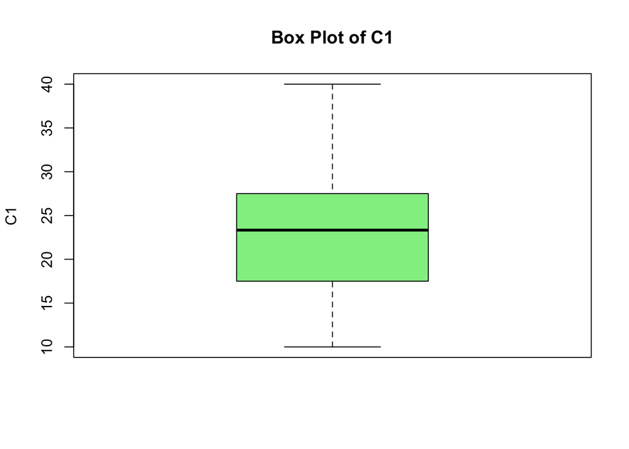

```r
boxplot(gradebook$C1, main = "Box Plot of C1", ylab = "C1" , col = "lightgreen")
```

# Take Home Assignment:

# Loading the dataset R_test_data.csv

```r
data <- read.csv("/Users/azharmadanisyed/Downloads/Data Mining/R_test_data.csv")
data
```

```r
# Removing the first unnecessary column
install.packages("dplyr")
```

```
## Error in install.packages : Updating loaded packages
```

```r
library(dplyr)
data <- data %>% select(-X)
```

```r
data
```

# Let’s perform data cleaning process

```r
# Dimension of the data
dim(data)
```

```
## [1] 30641    14
```

# Understanding more about the data

```r
# First five rows of the data
head(data)
```

# Summary of the data

```r
# Install and load the skimr package
install.packages("skimr")
```

```
## Error in install.packages : Updating loaded packages
```

```r
library(skimr)
```

```r
# Use skim to summarize the data
skim(data)
```

Data summary

| Name | data |
| --- | --- |
| Number of rows | 30641 |
| Number of columns | 14 |
| _______________________ |  |
| Column type frequency: |  |
| character | 10 |
| numeric | 4 |
| ________________________ |  |
| Group variables | None |

**Variable type: character**

| skim_variable | n_missing | complete_rate | min | max | empty | n_unique | whitespace |
| --- | --- | --- | --- | --- | --- | --- | --- |
| Gender | 0 | 1 | 4 | 6 | 0 | 2 | 0 |
| EthnicGroup | 0 | 1 | 0 | 7 | 1840 | 6 | 0 |
| ParentEduc | 0 | 1 | 0 | 18 | 1845 | 7 | 0 |
| LunchType | 0 | 1 | 8 | 12 | 0 | 2 | 0 |
| TestPrep | 0 | 1 | 0 | 9 | 1830 | 3 | 0 |
| ParentMaritalStatus | 0 | 1 | 0 | 8 | 1190 | 5 | 0 |
| PracticeSport | 0 | 1 | 0 | 9 | 631 | 4 | 0 |
| IsFirstChild | 0 | 1 | 0 | 3 | 904 | 3 | 0 |
| TransportMeans | 0 | 1 | 0 | 10 | 3134 | 3 | 0 |
| WklyStudyHours | 0 | 1 | 0 | 6 | 955 | 4 | 0 |

**Variable type: numeric**

| skim_variable | n_missing | complete_rate | mean | sd | p0 | p25 | p50 | p75 | p100 | hist |
| --- | --- | --- | --- | --- | --- | --- | --- | --- | --- | --- |
| NrSiblings | 1572 | 0.95 | 2.15 | 1.46 | 0 | 1 | 2 | 3 | 7 | ▇▅▆▁▁ |
| MathScore | 0 | 1.00 | 66.56 | 15.36 | 0 | 56 | 67 | 78 | 100 | ▁▁▅▇▃ |
| ReadingScore | 0 | 1.00 | 69.38 | 14.76 | 10 | 59 | 70 | 80 | 100 | ▁▁▆▇▃ |
| WritingScore | 0 | 1.00 | 68.42 | 15.44 | 4 | 58 | 69 | 79 | 100 | ▁▁▅▇▅ |

# Checking for missing values

```r
# Check for missing values in the entire data frame
```

```r
data
```

# We can see there are missing values in almost all the columns, but they haven’t been named anything (N/A), We can replace these values with NaN values, and then replace/impute of miising values depending on the number of missing values.

```r
sum(is.na(data))
```

```
## [1] 1572
```

```r
# Count missing values in each column
colSums(is.na(data))
```

```
##              Gender         EthnicGroup          ParentEduc           LunchType            TestPrep ParentMaritalStatus       PracticeSport
##                   0                   0                   0                   0                   0                   0                   0
##        IsFirstChild          NrSiblings      TransportMeans      WklyStudyHours           MathScore        ReadingScore        WritingScore
##                   0                1572                   0                   0                   0                   0                   0
```

# These values are misleading us, that there are no null values in the data, so first lets replace them with N/A.

```r
data[data == ""] <- NA
data
```

```r
sum(is.na(data))
```

```
## [1] 13901
```

```r
colSums(is.na(data))
```

```
##              Gender         EthnicGroup          ParentEduc           LunchType            TestPrep ParentMaritalStatus       PracticeSport
##                   0                1840                1845                   0                1830                1190                 631
##        IsFirstChild          NrSiblings      TransportMeans      WklyStudyHours           MathScore        ReadingScore        WritingScore
##                 904                1572                3134                 955                   0                   0                   0
```

# Now we got the correct number of missing values in the dataset.

# There are no missing values in the last three numerical columns…

# For numerical, only NrSiblings have the null values…we shall replace them with mean/median values.

# For Categorical, there are bunch of missing values..which we shall replace by mode or bfill/ffill values

```r
#Checking the structure of the data/datatypes
str(data)
```

```
## 'data.frame':    30641 obs. of  14 variables:
##  $ Gender             : chr  "female" "female" "female" "male" ...
##  $ EthnicGroup        : chr  NA "group C" "group B" "group A" ...
##  $ ParentEduc         : chr  "bachelor's degree" "some college" "master's degree" "associate's degree" ...
##  $ LunchType          : chr  "standard" "standard" "standard" "free/reduced" ...
##  $ TestPrep           : chr  "none" NA "none" "none" ...
##  $ ParentMaritalStatus: chr  "married" "married" "single" "married" ...
##  $ PracticeSport      : chr  "regularly" "sometimes" "sometimes" "never" ...
##  $ IsFirstChild       : chr  "yes" "yes" "yes" "no" ...
##  $ NrSiblings         : int  3 0 4 1 0 1 1 1 3 NA ...
##  $ TransportMeans     : chr  "school_bus" NA "school_bus" NA ...
##  $ WklyStudyHours     : chr  "< 5" "5 - 10" "< 5" "5 - 10" ...
##  $ MathScore          : int  71 69 87 45 76 73 85 41 65 37 ...
##  $ ReadingScore       : int  71 90 93 56 78 84 93 43 64 59 ...
##  $ WritingScore       : int  74 88 91 42 75 79 89 39 68 50 ...
```

```r
# No missing values here
sum(is.na(data$MathScore))
```

```
## [1] 0
```

```r
sum(is.na(data$ReadingScore))
```

```
## [1] 0
```

```r
sum(is.na(data$WritingScore))
```

```
## [1] 0
```

```r
sum(is.na(data$NrSiblings))
```

```
## [1] 1572
```

```r
# Lets replace this using median imputation
data$NrSiblings[is.na(data$NrSiblings)] <- median(data$NrSiblings, na.rm = TRUE)
colSums(is.na(data))
```

```
##              Gender         EthnicGroup          ParentEduc           LunchType            TestPrep ParentMaritalStatus       PracticeSport
##                   0                1840                1845                   0                1830                1190                 631
##        IsFirstChild          NrSiblings      TransportMeans      WklyStudyHours           MathScore        ReadingScore        WritingScore
##                 904                   0                3134                 955                   0                   0                   0
```

# All the numerical columns have been imputed.

# Let’s replace the categorical columns with the mode values.

```r
# Categorical columns
categorical_columns <- data %>% select_if(is.character)
categorical_columns
```

```r
# Step 1: Define a function to find the mode (most frequent value)
mode_function <- function(x) {
  ux <- unique(x)
  ux[which.max(tabulate(match(x, ux)))]
}
```

```r
# Step 2: Apply mode imputation to all selected categorical columns
# Loop through each column in the categorical data frame
for (col in names(categorical_columns)) {
  data[[col]][is.na(data[[col]])] <- mode_function(data[[col]])
}

# Step 3: Verify the changes
# Check to confirm that the missing values have been filled
colSums(is.na(data))
```

```
##              Gender         EthnicGroup          ParentEduc           LunchType            TestPrep ParentMaritalStatus       PracticeSport
##                   0                   0                   0                   0                   0                   0                   0
##        IsFirstChild          NrSiblings      TransportMeans      WklyStudyHours           MathScore        ReadingScore        WritingScore
##                   0                   0                   0                   0                   0                   0                   0
```

# Checking for the duplicate values

```r
sum(duplicated(data))
```

```
## [1] 1
```

```r
# Removing duplicates
data <- data[!duplicated(data), ]
```

```r
# Verify that no duplicates remain
sum(duplicated(data))
```

```
## [1] 0
```

# There was one duplicate value, we removed them.

# Checking for the outliers in the data.

# There are few outliers in all the features.

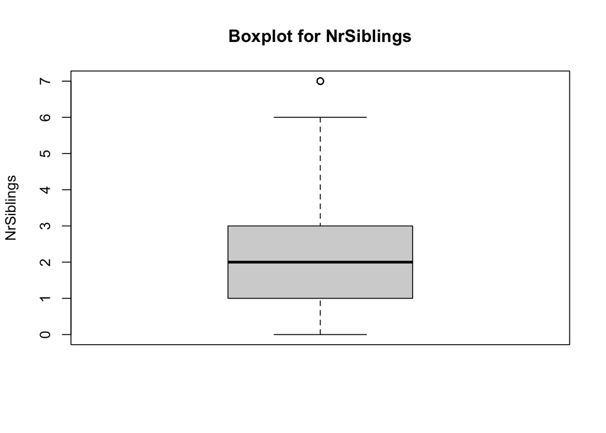

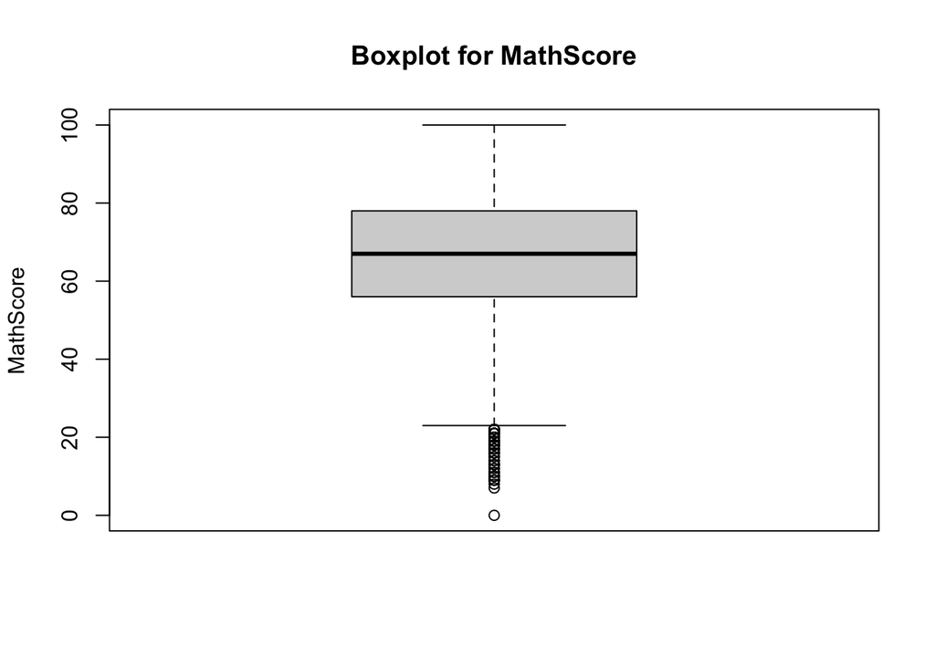

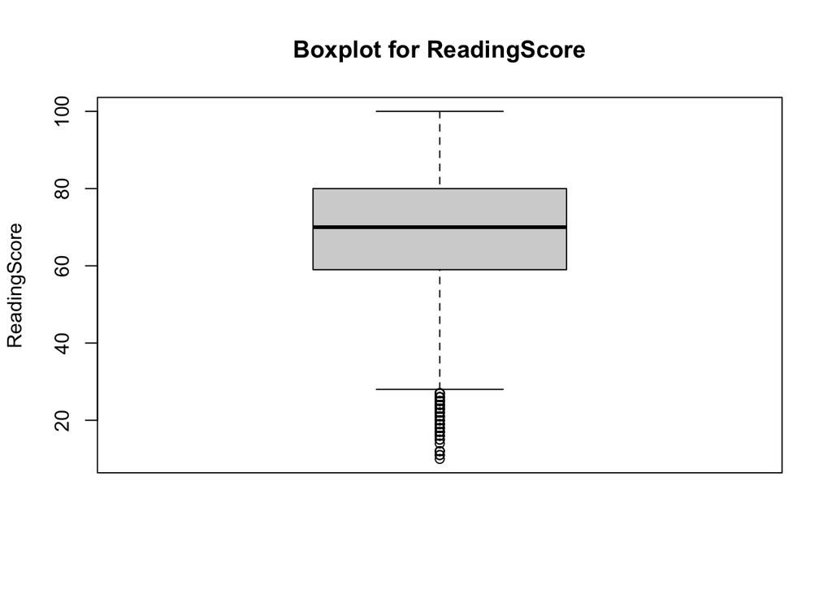

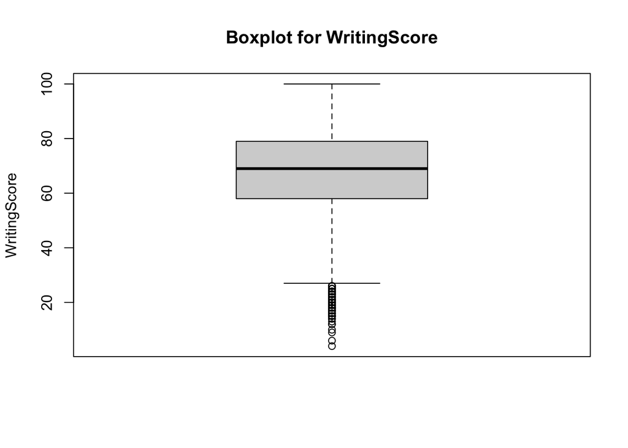

```r
# Use sapply to find columns with numeric data type
numeric_columns <- sapply(data, is.numeric)

# Loop through each numerical column and create boxplots
for (col in names(data)[numeric_columns]) {
    # Create a boxplot for each numerical column
    boxplot(data[[col]], main = paste("Boxplot for", col), ylab = col)
}
```

# Outlier detection in the numerical columns.

```r
# Define a function to identify and extract outliers based on the IQR method
get_outliers <- function(column_data) {
  # Calculate the first (Q1) and third (Q3) quartiles, and the interquartile range (IQR)
  Q1 <- quantile(column_data, 0.25, na.rm = TRUE)
  Q3 <- quantile(column_data, 0.75, na.rm = TRUE)
  IQR_value <- Q3 - Q1

  # Calculate the lower and upper bounds for outliers
  lower_bound <- Q1 - 1.5 * IQR_value
  upper_bound <- Q3 + 1.5 * IQR_value

  # Return the values that are outliers
  outliers <- column_data[column_data < lower_bound | column_data > upper_bound]
  return(outliers)
}

# Function to identify and display outliers for each numerical column in a dataset
identify_outliers <- function(data) {
  # Get the list of numerical columns in the data
  numerical_columns <- sapply(data, is.numeric)

  # Iterate through each numerical column and find outliers
  for (col_name in names(data)[numerical_columns]) {
    cat("Outliers for", col_name, ":\n")
    outliers <- get_outliers(data[[col_name]])

    # Display the outlier values, if any
    if (length(outliers) > 0) {
      print(outliers)
    } else {
      cat("No outliers found.\n")
    }
    cat("\n")  # Add a blank line for readability
  }
}

identify_outliers(data)
```

```
## Outliers for NrSiblings :
##   [1] 7 7 7 7 7 7 7 7 7 7 7 7 7 7 7 7 7 7 7 7 7 7 7 7 7 7 7 7 7 7 7 7 7 7 7 7 7 7 7 7 7 7 7 7 7 7 7 7 7 7 7 7 7 7 7 7 7 7 7 7 7 7 7 7 7 7 7 7
##  [69] 7 7 7 7 7 7 7 7 7 7 7 7 7 7 7 7 7 7 7 7 7 7 7 7 7 7 7 7 7 7 7 7 7 7 7 7 7 7 7 7 7 7 7 7 7 7 7 7 7 7 7 7 7 7 7 7 7 7 7 7 7 7 7 7 7 7 7 7
## [137] 7 7 7 7 7 7 7 7 7 7 7 7 7 7 7 7 7 7 7 7 7 7 7 7 7 7 7 7 7 7 7 7 7 7 7 7 7 7 7 7 7 7 7 7 7 7 7 7 7 7 7 7 7 7 7 7 7 7 7 7 7 7 7 7 7 7 7 7
## [205] 7 7 7 7 7 7 7 7 7 7 7 7 7 7 7 7 7 7 7 7 7 7 7 7 7 7 7 7 7 7 7 7 7 7 7 7 7 7 7 7 7 7 7 7 7 7 7 7 7 7 7 7 7 7 7 7 7 7 7 7 7 7 7 7 7 7 7 7
## [273] 7 7 7 7 7 7 7 7 7 7 7 7 7 7 7 7 7 7 7
##
## Outliers for MathScore :
##  [1] 18  0 21 18  8 21 22 17 20 16 21 21 22 19 22 22 22 17 20 15 15 18 18 11 19 12 12 13 18 22 17 19 21 21  9 18 21 22 10  7 22 21 17 22 10
## [46] 22 14 14 19 19 11  9 10 13 18 20 21 16 13 22 13 22 10 16 21 21 16 18 20 19  9 19 11  9 21 19
##
## Outliers for ReadingScore :
##  [1] 17 25 23 24 24 26 23 21 18 25 15 23 24 11 17 24 23 26 24 17 20 24 24 25 19 25 16 20 22 26 22 27 27 23 22 23 19 23 24 11 27 24 26 22 27
## [46] 23 17 23 12 12 18 23 16 27 23 23 21 20 20 26 26 21 23 26 27 24 27 16 23 24 23 12 26 15 21 27 17 25 18 19 10 25 23 25 25 26 18 14 25 19
##
## Outliers for WritingScore :
##   [1] 10 21 19 26 15 23 17 25 26 24 15 20 21 25 24 23  6 17 24 22 22 21 25 14 26 25 18 16 19 23 26 19 24 14 17 26 24 24 21 24 23 15 26 24 18
##  [46] 19 20 21 24 15 24 12 22 25 18 16 24 26 17 19 24 18  9 19 20 25 18 21 23 19 16 18 25 23 20 20 20 22 26 26 26 24 26 25 18 20 23 24 23 17
##  [91] 15 21 12 25 16 25 20 18 13 26 20 23 21 26 26 22  4 20 24
```

# Sublings can be 7, so I don’t consider this as an outlier.

# There are different range of values in Mathscore, reading and writing, a person who did not study well has the chances of getting less values. So, these are also the correct values.

# Inspecting the categorical column values

```r
categorical_columns <- c("Gender", "EthnicGroup", "TestPrep", "TransportMeans", "LunchType",
                         "ParentMaritalStatus", "PracticeSport", "IsFirstChild")
for (col in categorical_columns) {
    cat("Unique values in", col, ":\n")
    print(unique(data[[col]]))
    cat("\n")
}
```

```
## Unique values in Gender :
## [1] "female" "male"
##
## Unique values in EthnicGroup :
## [1] "group C" "group B" "group A" "group D" "group E"
##
## Unique values in TestPrep :
## [1] "none"      "completed"
##
## Unique values in TransportMeans :
## [1] "school_bus" "private"
##
## Unique values in LunchType :
## [1] "standard"     "free/reduced"
##
## Unique values in ParentMaritalStatus :
## [1] "married"  "single"   "widowed"  "divorced"
##
## Unique values in PracticeSport :
## [1] "regularly" "sometimes" "never"
##
## Unique values in IsFirstChild :
## [1] "yes" "no"
```

# All the values look okay for me.

# Exploratory Data Analysis

# 1. Numerical Columns (Histograms)

# This plots gives us the picture of how well the data is distributed across the varaibles.

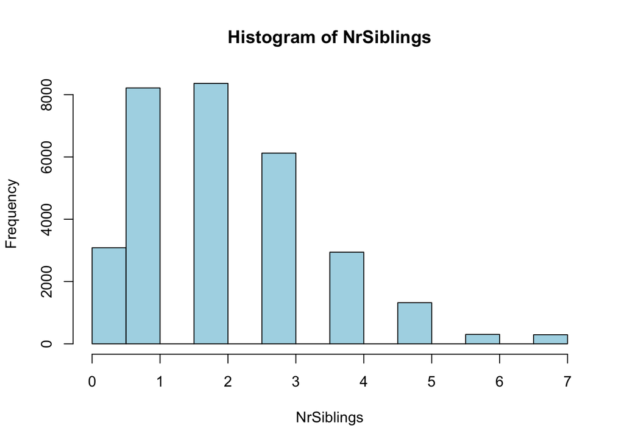

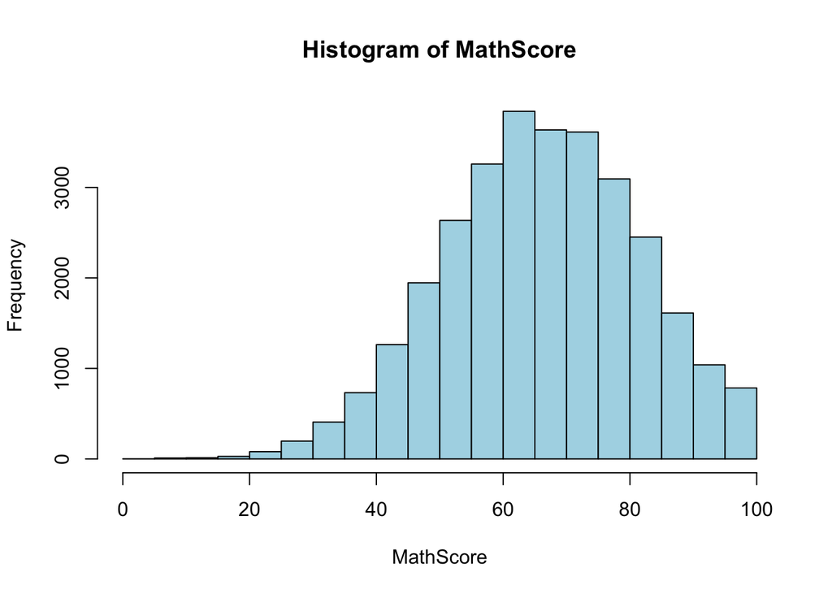

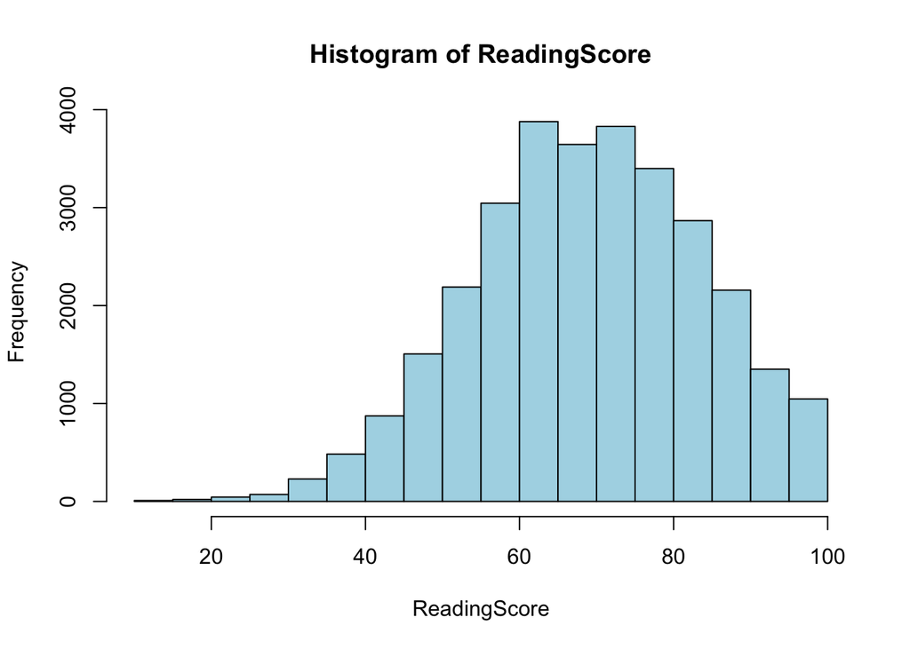

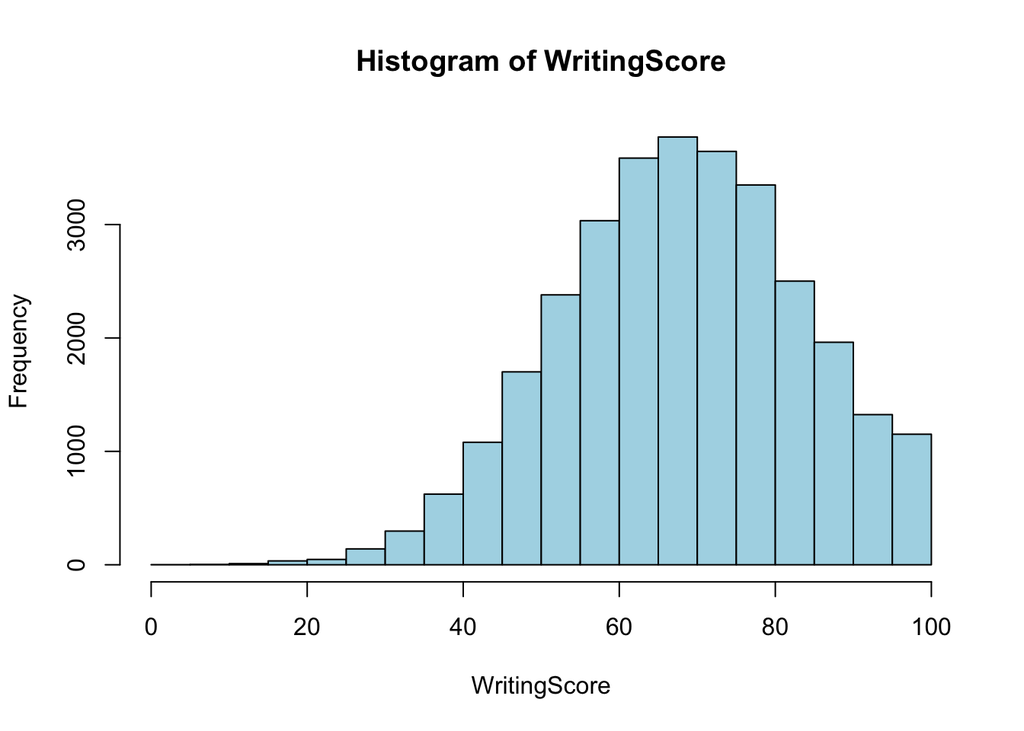

```r
# Plot histograms for all numerical columns
numeric_columns <- sapply(data, is.numeric)
for (col in names(data)[numeric_columns]) {
    hist(data[[col]], main = paste("Histogram of", col), xlab = col, col = "lightblue", breaks = 20)
}
```

# 2. Categorical Variables (Bar plots)

# It gives the count of each category for the variables.

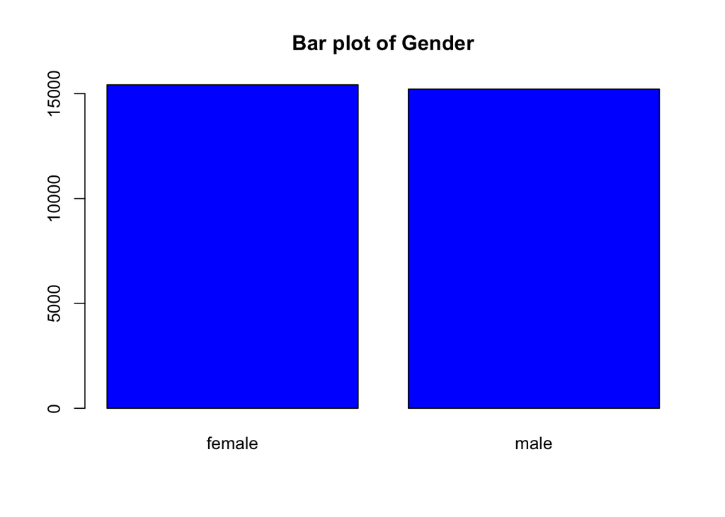

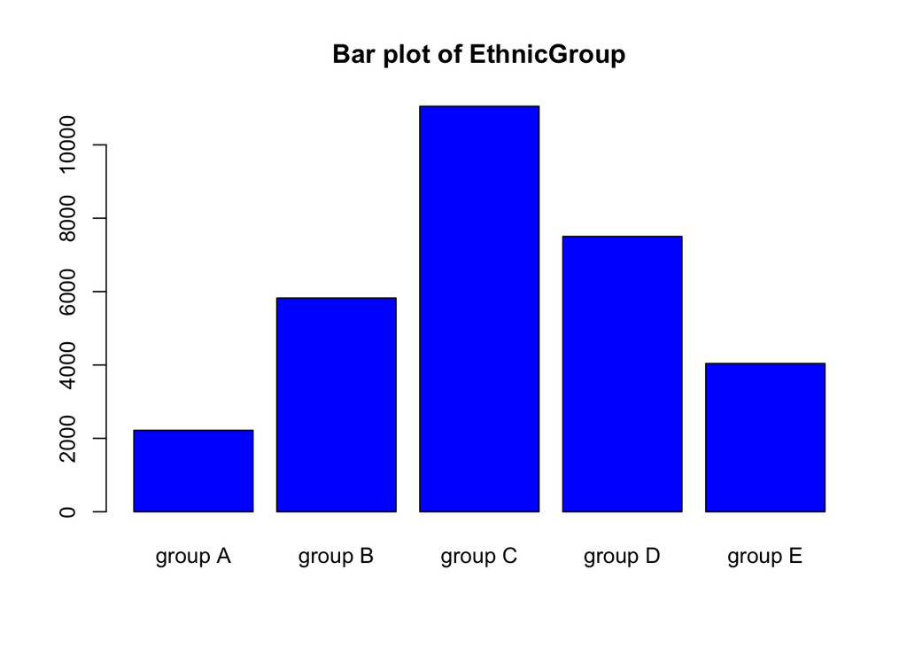

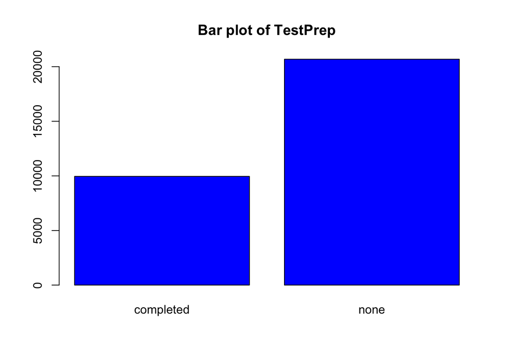

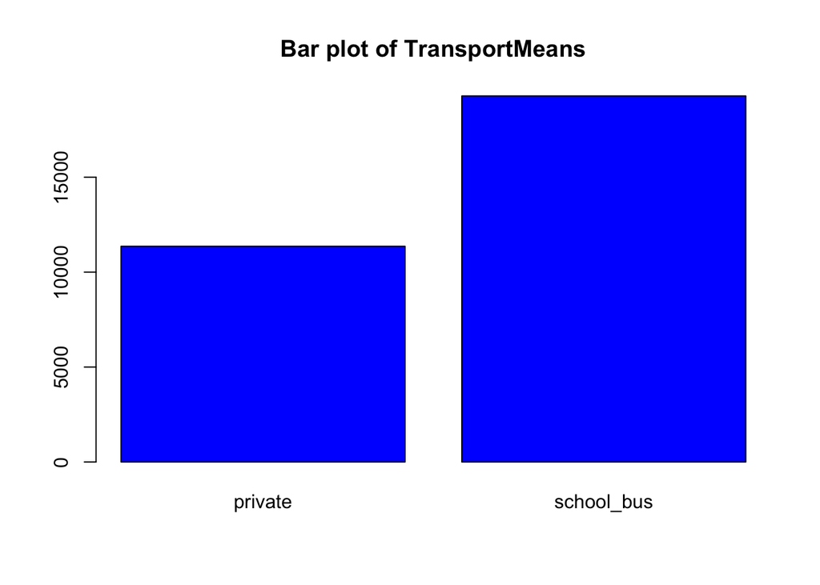

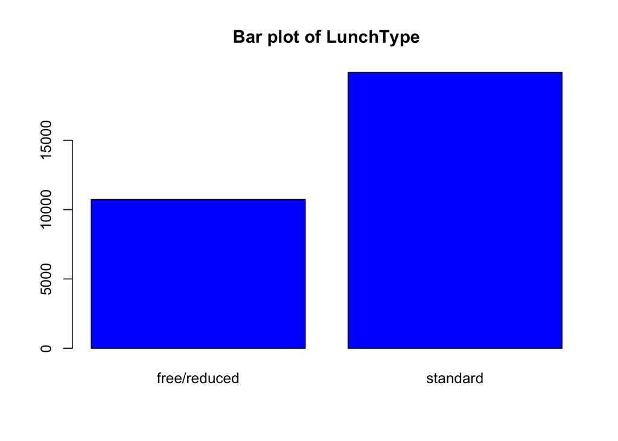

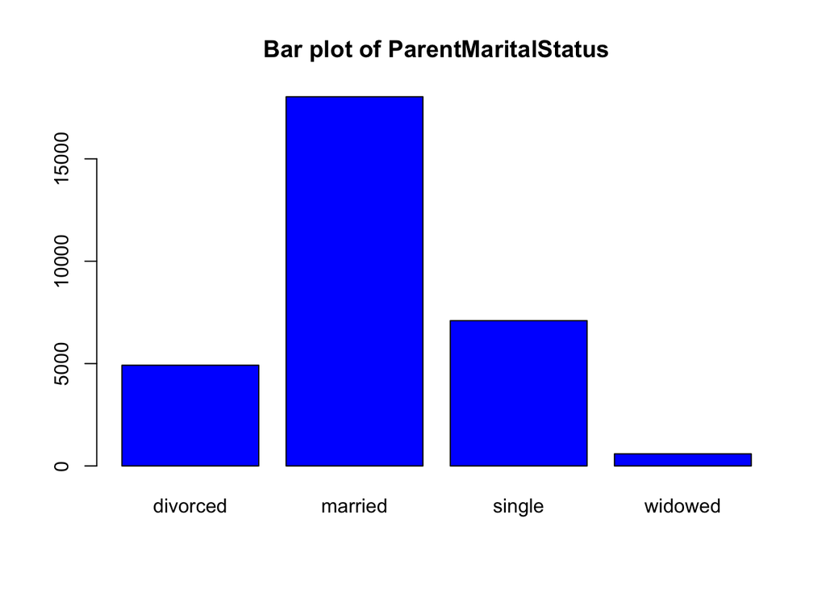

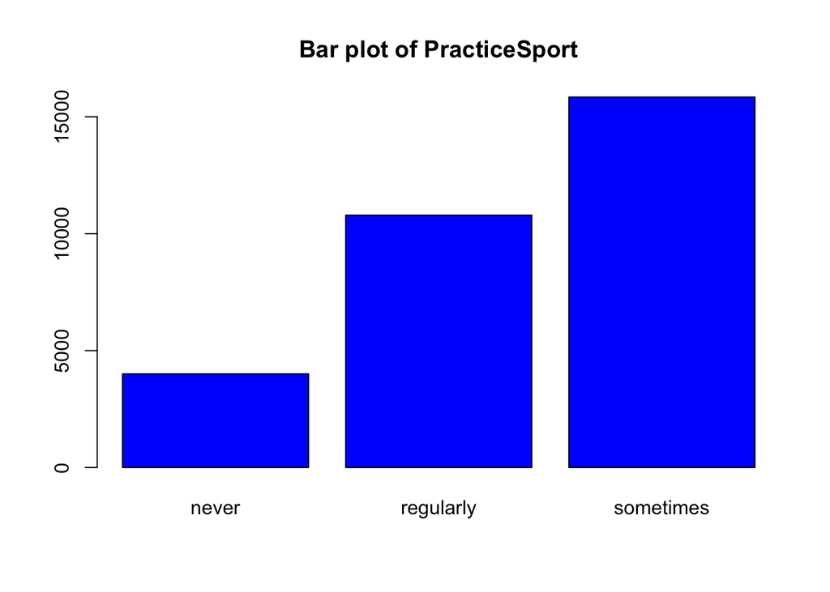

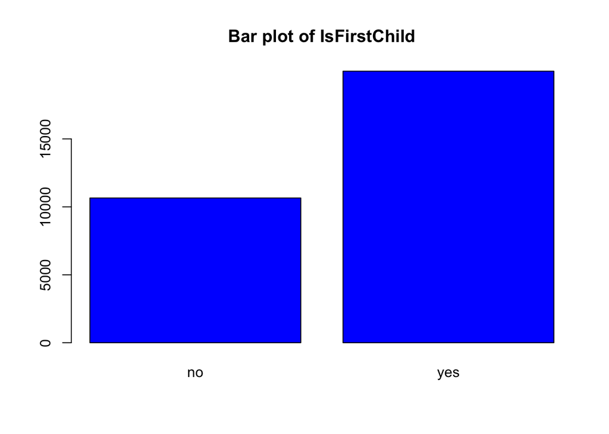

```r
# Plot bar charts for categorical variables

for (col in categorical_columns) {
    barplot(table(data[[col]]), main = paste("Bar plot of", col), col ="blue")
}
```

# Correlation Matrix:

# Correlation Matrix helps is understanding whether there is any correlation (linear relationship) between the numerical variables.

```r
# Create a correlation matrix for numerical variables
cor_matrix <- cor(data[, numeric_columns], use = "complete.obs")
print(cor_matrix)
```

```
##                 NrSiblings    MathScore  ReadingScore WritingScore
## NrSiblings    1.0000000000 -0.001114399 -0.0008050999 -0.002392315
## MathScore    -0.0011143990  1.000000000  0.8178304979  0.807116247
## ReadingScore -0.0008050999  0.817830498  1.0000000000  0.952585541
## WritingScore -0.0023923147  0.807116247  0.9525855406  1.000000000
```

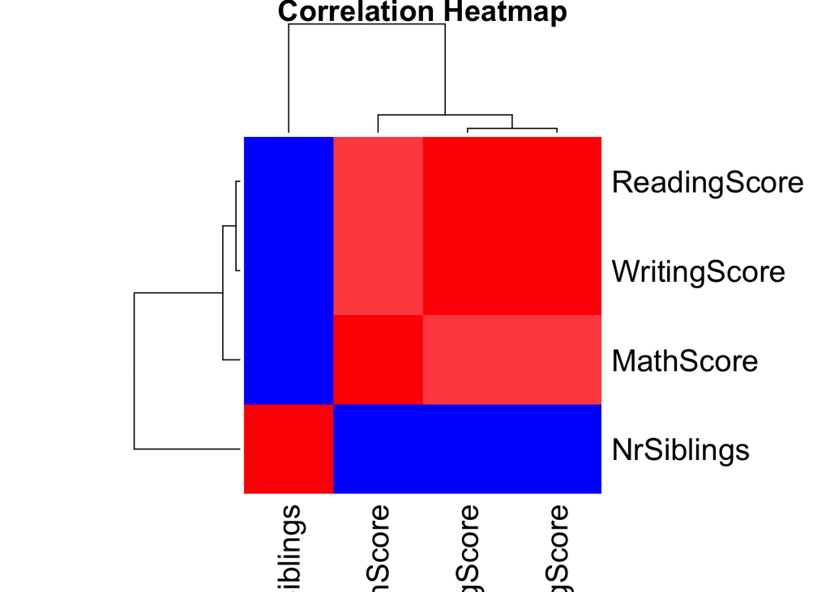

```r
# Visualize the correlation matrix using a heatmap
heatmap(cor_matrix, main = "Correlation Heatmap", col = colorRampPalette(c("blue", "white", "red"))(20), scale = "none")
```

# Summary of the what I have done:

- Loaded the dataset in csv format.
- Checked the dimension, head and summary of the data.
- Checked if there are any missing values in the dataset and then removed them using median method for numerical variables and mode for the categorical variables.
- Checked if there are any duplicates in the data and then removed them.
- Checked the outliers and evaluated by checking them, I found them as the valid numbers, so decided not to drop them.
- Finally performed Exploratory data Analysis: Histograms, Barplots, and Correlation matrix.

# Saving Data Frame as CSV file

```r
write.csv(data, "/Users/azharmadanisyed/Downloads/Data Mining/R_test_data_cleaned.csv", row.names = FALSE)
```

# I got the cleaned R test data in the csv format.